# Final Project Knit

Nathan Riojas, Ryan Billa, Corey Monreal-Jackson

December 8, 2015

### Project WebApp Link

[Shiny Data Visualizations](https://nathanriojas.shinyapps.io/DVFinal)

# Tableau Visuals

## Scatter Plot

### (start with 2 green things) -also demonstrates Maps, Actions, Dashboards, and the Analytics Tab - Models and Forecasting

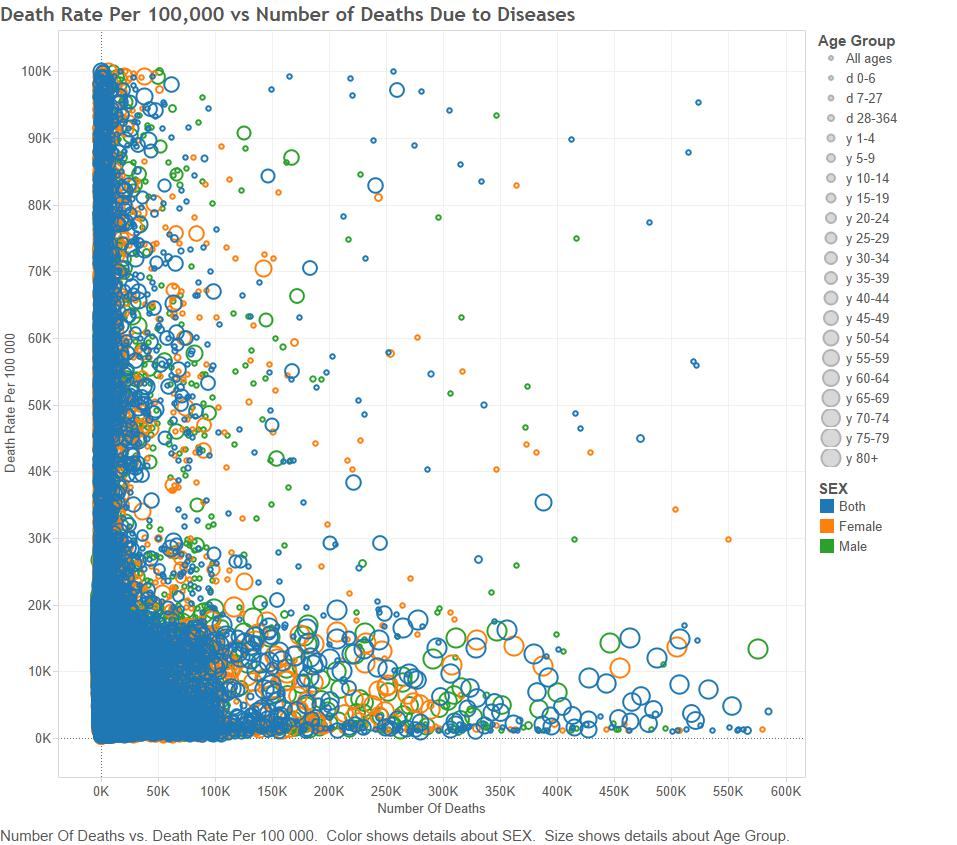

## Barchart

### (start with a blue thing and a green thing) - also demonstrate Table Calculations, the Analytics Tab - Reference Lines, ID Sets, and Formatting

### Compares the countries with their death rates per 100,000 separated by sex

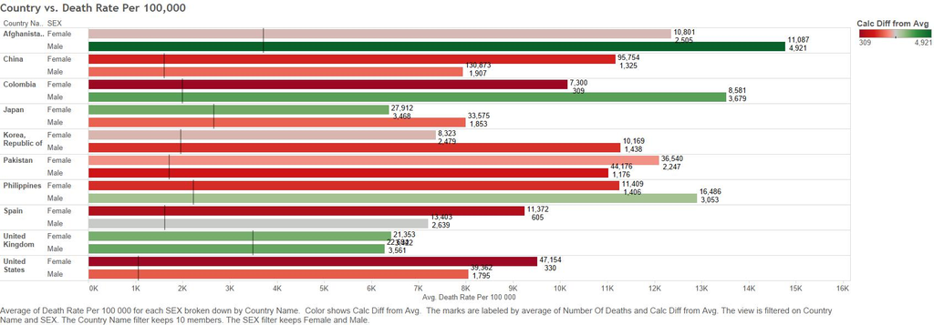

## Crosstabs

### (start with two blue things and a green thing) - also demonstrates Key Performance Indicators (KPIs), Calculated Fields, Sets, Parameters, and Hierarchies

### Shows the number of deaths, death rate and calculated death rate for different age groups and countries

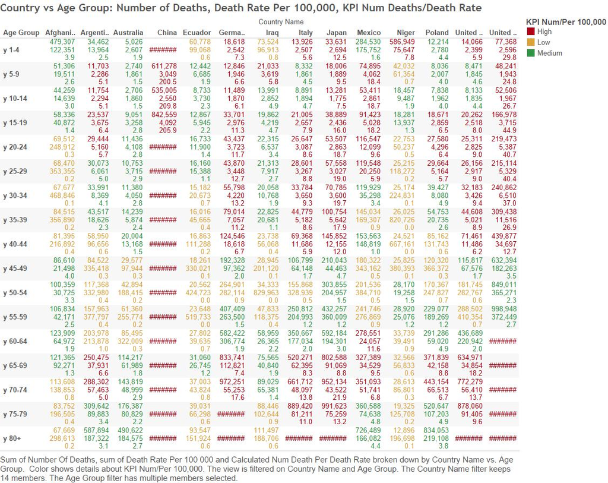

## Data Blending

### joining data together

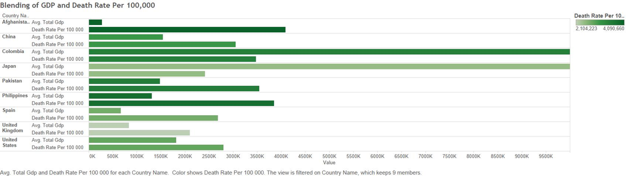

## Aggregated Measures Analysis

### (start with a green thing) - also demonstrates Histograms, Dual-axis Plots and Show Me

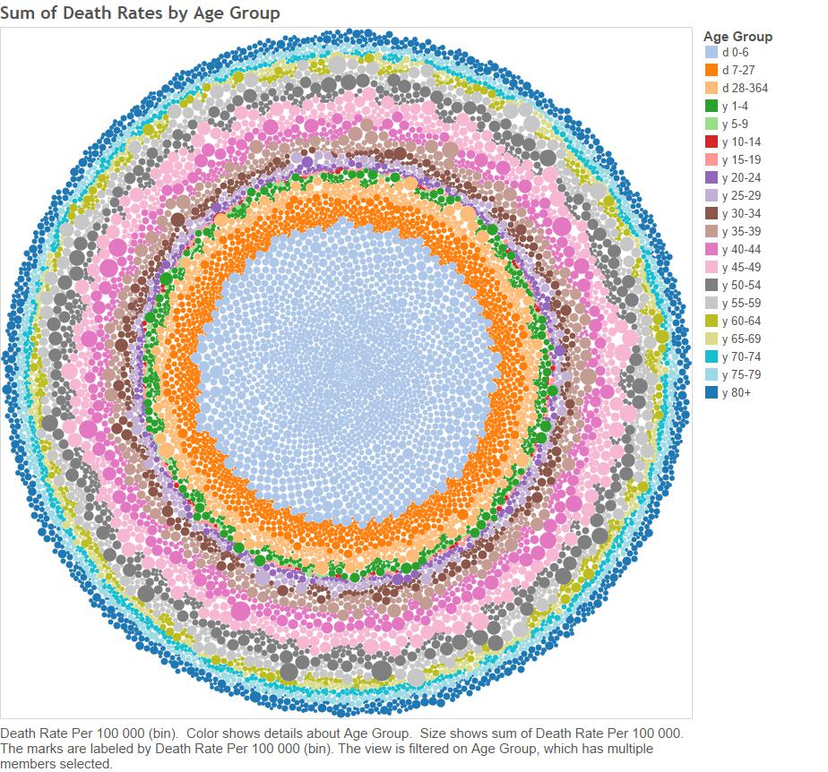

## Map

### (start with a green thing [measure] and a blue thing [dimension] under show me click filled maps)

### There is a page setup for year that does decades 1970-2010

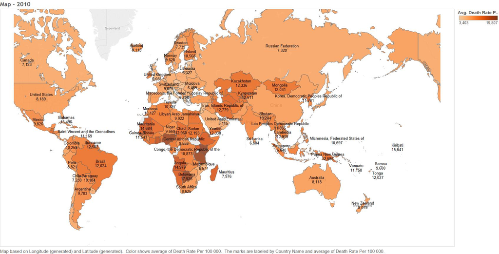

## Non-Aggregated Measures Analysis

### (start with a green thing) - also demonstrates Boxplots, Dates, and Pages

### Distribution of the data through the different quartile ranges, separated by sex

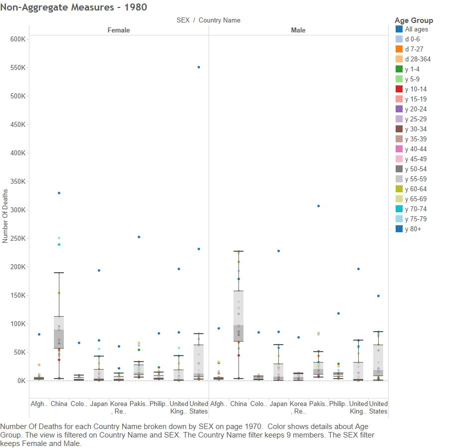

#### The following code is the code from the files in our project

### ETL code

```
#setwd("C:/Users/Nathan R/Documents/DataVisualization/Project 4/01 Data/CSVs")

#file_path <- "Effect of Disease Country Pop.csv"

#df <- read.csv(file_path, stringsAsFactors = FALSE)

##Replace "." (i.e., period) with "_" in the column names.
#names(df) <- gsub("\\.+", "_", names(df))

#str(df) # Uncomment this and  run just the lines to here to get column types to use for getting the list of measures.

#measures <- c("Year","Number of Deaths", "Death Rate Per 100,000")
##measures <- NA # Do this if there are no measures.

##Get rid of special characters in each column.
##Google ASCII Table to understand the following:
#for(n in names(df)) {
#  df[n] <- data.frame(lapply(df[n], gsub, pattern="[^ -~]",replacement= ""))
#}

#dimensions <- setdiff(names(df), measures)
#if( length(measures) > 1 || ! is.na(dimensions)) {
#  for(d in dimensions) {
#    # Get rid of " and ' in dimensions.
#    df[d] <- data.frame(lapply(df[d], gsub, pattern="[\"']",replacement= ""))
#    # Change & to and in dimensions.
#    df[d] <- data.frame(lapply(df[d], gsub, pattern="&",replacement= " and "))
#    # Change : to ; in dimensions.
#    df[d] <- data.frame(lapply(df[d], gsub, pattern=":",replacement= ";"))
#  }
#}

#library(lubridate)
##Fix date columns, this needs to be done by hand because | needs to be correct.
##                                                      \_/


##The following is an example of dealing with special cases like making state abbreviations be all upper case.
##df["State"] <- data.frame(lapply(df["State"], toupper))

```

[output cut: 9 more lines]

```
#tableName <- gsub(" +", "_", gsub("[^A-z, 0-9, ]", "", gsub(".csv", "", file_path)))
#sql <- paste("CREATE TABLE", tableName, "(\n-- Change table_name to the table name you want.\n")
#if( length(measures) > 1 || ! is.na(dimensions)) {
#  for(d in dimensions) {
#    sql <- paste(sql, paste(d, "varchar2(4000),\n"))
#  }
#}
#if( length(measures) > 1 || ! is.na(measures)) {
#  for(m in measures) {
#    if(m != tail(measures, n=1)) sql <- paste(sql, paste(m, "number(38,4),\n"))
#    else sql <- paste(sql, paste(m, "number(38,4)\n"))
#  }
#}
#sql <- paste(sql, ");")
#cat(sql)
```

```
#require(tidyr)
#require(dplyr)
#require(ggplot2)

#setwd("C:/Users/Nathan R/Documents/DataVisualization/Project 4/01 Data/CSVs")

#file_path <- "Country GDP.csv"

#df <- read.csv(file_path, stringsAsFactors = FALSE)

## Replace "." (i.e., period) with "_" in the column names.
#names(df) <- gsub("\\.+", "_", names(df))

## str(df) # Uncomment this and  run just the lines to here to get column types to use for getting the list of measures.

#measures <- c("2005", "2006", "2007", "2008", "2009", "2010" , "2011", "2012", "2013", "2014", "2015", "2016", "2017", #"2018", "2019", "2020")
##measures <- NA # Do this if there are no measures.

## Get rid of special characters in each column.
## Google ASCII Table to understand the following:
#for(n in names(df)) {
#  df[n] <- data.frame(lapply(df[n], gsub, pattern="[^ -~]",replacement= ""))
#}

#dimensions <- setdiff(names(df), measures)
#if( length(measures) > 1 || ! is.na(dimensions)) {
#  for(d in dimensions) {
#    # Get rid of " and ' in dimensions.
#    df[d] <- data.frame(lapply(df[d], gsub, pattern="[\"']",replacement= ""))
#    # Change & to and in dimensions.
#    df[d] <- data.frame(lapply(df[d], gsub, pattern="&",replacement= " and "))
#    # Change : to ; in dimensions.
#    df[d] <- data.frame(lapply(df[d], gsub, pattern=":",replacement= ";"))
#  }
#}

#library(lubridate)
## Fix date columns, this needs to be done by hand because | needs to be correct.
##                                                        \_/
#df$Order_Date <- gsub(" [0-9]+:.*", "", gsub(" UTC", "", mdy(as.character(df$Order_Date), tz="UTC")))
```

[output cut: 14 more lines]

```
#tableName <- gsub(" +", "_", gsub("[^A-z, 0-9, ]", "", gsub(".csv", "", file_path)))
#sql <- paste("CREATE TABLE", tableName, "(\n-- Change table_name to the table name you want.\n")
#if( length(measures) > 1 || ! is.na(dimensions)) {
#  for(d in dimensions) {
#    sql <- paste(sql, paste(d, "varchar2(4000),\n"))
#  }
#}
#if( length(measures) > 1 || ! is.na(measures)) {
#  for(m in measures) {
#    if(m != tail(measures, n=1)) sql <- paste(sql, paste(m, "number(38,4),\n"))
#    else sql <- paste(sql, paste(m, "number(38,4)\n"))
#  }
#}
#sql <- paste(sql, ");")
#cat(sql)
```

```
setwd("C:/Users/Nathan R/Documents/DataVisualization/Final Project/01 Data")

file_path <- "Fortune 500 Companies.csv"

df <- read.csv(file_path, stringsAsFactors = FALSE)

#Replace "." (i.e., period) with "_" in the column names.
names(df) <- gsub("\\.+", "_", names(df))

#str(df) # Uncomment this and  run just the lines to here to get column types to use for getting the list of measures.

measures <- c("Year", "Rank")
#measures <- NA # Do this if there are no measures.

#Get rid of special characters in each column.
#Google ASCII Table to understand the following:
for(n in names(df)) {
  df[n] <- data.frame(lapply(df[n], gsub, pattern="[^ -~]",replacement= ""))
}

dimensions <- setdiff(names(df), measures)
if( length(measures) > 1 || ! is.na(dimensions)) {
  for(d in dimensions) {
    # Get rid of " and ' in dimensions.
    df[d] <- data.frame(lapply(df[d], gsub, pattern="[\"']",replacement= ""))
    # Change & to and in dimensions.
    df[d] <- data.frame(lapply(df[d], gsub, pattern="&",replacement= " and "))
    # Change : to ; in dimensions.
    df[d] <- data.frame(lapply(df[d], gsub, pattern=":",replacement= ";"))
  }
}

library(lubridate)
#Fix date columns, this needs to be done by hand because | needs to be correct.
#                                                      \_/


#The following is an example of dealing with special cases like making state abbreviations be all upper case.
df["State"] <- data.frame(lapply(df["State"], toupper))

```

[output cut: 9 more lines]

```
tableName <- gsub(" +", "_", gsub("[^A-z, 0-9, ]", "", gsub(".csv", "", file_path)))
sql <- paste("CREATE TABLE", tableName, "(\n-- Change table_name to the table name you want.\n")
if( length(measures) > 1 || ! is.na(dimensions)) {
  for(d in dimensions) {
    sql <- paste(sql, paste(d, "varchar2(4000),\n"))
  }
}
if( length(measures) > 1 || ! is.na(measures)) {
  for(m in measures) {
    if(m != tail(measures, n=1)) sql <- paste(sql, paste(m, "number(38,4),\n"))
    else sql <- paste(sql, paste(m, "number(38,4)\n"))
  }
}
sql <- paste(sql, ");")
cat(sql)
```

```r
source("../00 Doc/Rprofile.R", echo = TRUE)
```

```
##
## > require("ggplot2")
```

```
##
## > require("ggthemes")
```

```
##
## > require("gplots")
```

```
##
## > require("grid")
```

```
##
## > require("RCurl")
```

```
##
## > require("reshape2")
```

```
##
## > require("tableplot")
```

```
##
## > require("tidyr")
```

```
##
## > require("dplyr")
```

```
##
## > require("jsonlite")
```

```
##
## > require("extrafont")
```

```
## Registering fonts with R
```

```
##
## > require("lubridate")
```

```r
source("../01 Data/Dataframes.R", echo = TRUE)
```

```
##
## > require("jsonlite")
##
## > require("RCurl")
##
## > require("ggplot2")
##
## > death_df <- data.frame(fromJSON(getURL(URLencode("skipper.cs.utexas.edu:5001/rest/native/?query=\"select * from DISEASE where NUMBER_OF_DEATHS < 100 .... [TRUNCATED]
##
## > summary(death_df)
##   COUNTRY_CODE                COUNTRY_NAME      AGE_GROUP
##  ALB    :  315   Albania            :  315   y 10-14 : 2805
##  AND    :  315   Andorra            :  315   y 5-9   : 2801
##  ARE    :  315   Antigua and Barbuda:  315   y 15-19 : 2800
##  ARM    :  315   Armenia            :  315   y 20-24 : 2800
##  ATG    :  315   Australia          :  315   y 25-29 : 2800
##  AUS    :  315   Austria            :  315   y 30-34 : 2798
##  (Other):56161   (Other)            :56161   (Other) :41247
##      SEX             YEAR      NUMBER_OF_DEATHS DEATH_RATE_PER_100_000
##  Both  :19226   Min.   :1970   Min.   :    0    Min.   :  105.1
##  Female:19425   1st Qu.:1980   1st Qu.:  161    1st Qu.:  784.6
##  Male  :19400   Median :1990   Median :  976    Median : 2528.0
##                 Mean   :1990   Mean   : 5955    Mean   :10026.2
##                 3rd Qu.:2000   3rd Qu.: 4107    3rd Qu.:10327.7
##                 Max.   :2010   Max.   :99994    Max.   :99966.0
##
##
## > head(death_df)
##   COUNTRY_CODE COUNTRY_NAME AGE_GROUP    SEX YEAR NUMBER_OF_DEATHS
## 1          AFG  Afghanistan  y 20-24    Both 1990             4443
## 2          AFG  Afghanistan  y 25-29    Male 1990             1910
## 3          AFG  Afghanistan  y 25-29  Female 1990             2491
## 4          AFG  Afghanistan  y 25-29    Both 1990             4401
## 5          AFG  Afghanistan  y 30-34    Male 1990             1883
## 6          AFG  Afghanistan  y 30-34  Female 1990             2449
##   DEATH_RATE_PER_100_000
## 1               5040.044
## 2               4989.895
## 3              27042.641
## 4              11105.216
```

[output cut: 36 more lines]

```
##  Min.   :-23498
##  1st Qu.:  1610
##  Median :  2956
##  Mean   :  4634
##  3rd Qu.:  5548
##  Max.   : 45220
##
## > head(fortune)
##          COMPANY YEAR_ RANK_ REVENUE PROFIT
## 1 General Motors  1957     1 10796.4  847.4
## 2 General Motors  1955     1  9823.5  806.0
## 3 General Motors  1956     1 12443.3 1189.5
## 4 General Motors  1961     1 12736.0  959.0
## 5 General Motors  1958     1 10989.8  843.6
## 6 General Motors  1959     1  9522.0  633.6
```